# Causal Estimands

## The difference

### Estimand

[figure not shown]

@tigga_mac TikTok

### Estimator

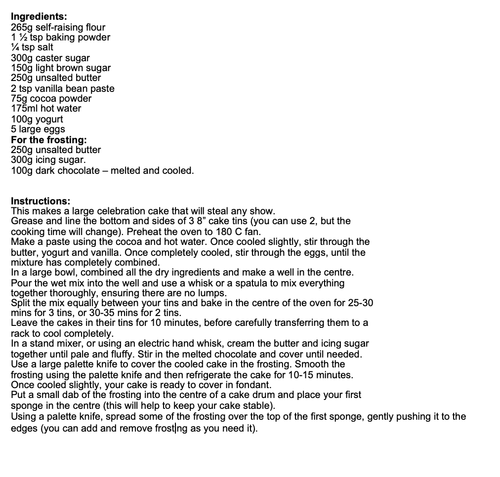

https://www.bluey.tv/make/bluey-celebration-cake/

### Estimate

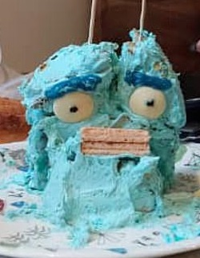

Coles Mudcake Hacks Facebook

[Home baker attempts to make a Bluey birthday cake using Woolies mudcakes - but is left in hysterics over her ‘abomination’ of a dessert](https://www.dailymail.co.uk/femail/food/article-11879919/Woolworths-mudcake-hack-Home-bakers-hilarious-Bluey-cake-fail-leaves-internet-stitches.html)

## The difference

### Estimand

$$E[Y(1) - Y(0)]$$

### Estimator

$$\sum_{i=1}^N\frac{Y_i\times X_i}{N_A}-\frac{Y_i \times(1 - X_i)}{N_B}$$

### Estimate

```r
library(tidyverse)
set.seed(928)
ab <- tibble(
  x = rbinom(100, 1, 0.5),
  y = x + rnorm(100)
)

ab |>
  summarise(
    n_a = sum(x),
    n_b = sum(1 - x),
    estimate = sum(
      (y * x) / n_a -
        y * (1 - x) / n_b
    )
  )
```

```
# A tibble: 1 × 3
    n_a   n_b estimate
  <int> <dbl>    <dbl>
1    54    46     1.15
```

## Weighted estimator

$$\frac{\sum_{i=1}^NY_i\times X_i\times w_i}{\sum_{i=1}^NX_i\times w_i}-\frac{\sum_{i=1}^NY_i\times(1-X_i)\times w_i}{\sum_{i=1}^N(1-X_i)\times w_i}$$

## Example

[figure not shown]

Photo by Anna [CC-BY-SA-4.0](https://creativecommons.org/licenses/by-sa/4.0/deed.en)

Historically, guests who stayed in a Walt Disney World resort hotel were able to access the park during “Extra Magic Hours” during which the park was closed to all other guests.

These extra hours could be in the morning or evening.

The Seven Dwarfs Mine Train is a ride at Walt Disney World’s Magic Kingdom. Typically, each day Magic Kingdom may or may not be selected to have these “Extra Magic Hours”.

**We are interested in examining the relationship between whether there were “Extra Magic Hours” in the morning and the average wait time for the Seven Dwarfs Mine Train the same day between 9am and 10am.**

## Average treatment effect

### Question

Should we make every day an extra magic morning (or not)?

### Estimand

$E[Y(1)-Y(0)]$

### Weight

$$w_{ATE} = \frac{X}{p} + \frac{(1 - X)}{1 - p}$$

## ATE weighted table

| **Characteristic** | **No Magic Hours** N = 354<sup>1</sup> | **Extra Magic Hours** N = 357<sup>1</sup> | **Overall** N = 711<sup>1</sup> |
| --- | --- | --- | --- |
| park_ticket_season |  |  |  |
| peak | 78 (22%) | 81 (23%) | 160 (22%) |
| regular | 193 (54%) | 187 (52%) | 380 (53%) |
| value | 83 (23%) | 89 (25%) | 172 (24%) |
| park_close |  |  |  |
| 16:30:00 | 2 (0.4%) | 0 (0%) | 2 (0.2%) |
| 18:00:00 | 50 (14%) | 72 (20%) | 122 (17%) |
| 20:00:00 | 20 (5.6%) | 19 (5.3%) | 39 (5.5%) |
| 21:00:00 | 31 (8.7%) | 0 (0%) | 31 (4.3%) |
| 22:00:00 | 108 (30%) | 86 (24%) | 193 (27%) |
| 23:00:00 | 95 (27%) | 81 (23%) | 176 (25%) |
| 24:00:00 | 48 (14%) | 94 (26%) | 142 (20%) |
| 25:00:00 | 1 (0.3%) | 6 (1.6%) | 7 (1.0%) |
| park_temperature_high | 84 (78, 89) | 83 (78, 87) | 84 (78, 88) |

<sup>1</sup> n (%); Median (Q1, Q3)

## ATE weighted histogram

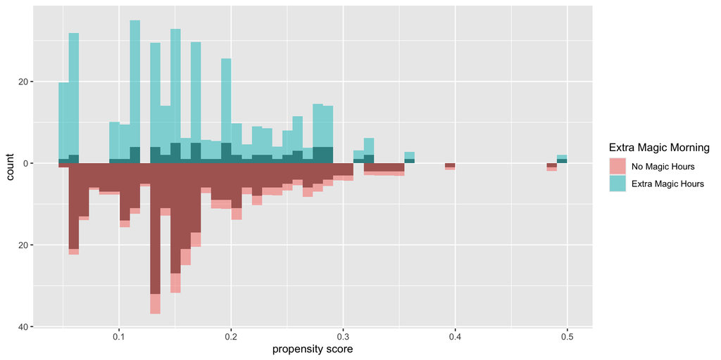

## Average treatment effect among the treated

### Question

Should we stop extra magic hours on days that have them?

### Estimand

$E[Y(1)-Y(0) | X = 1]$

### Weight

$$w_{ATT} = X + \frac{(1 - X)p}{1 - p}$$

## ATT weighted table

| **Characteristic** | **No Magic Hours** N = 60<sup>1</sup> | **Extra Magic Hours** N = 60<sup>1</sup> | **Overall** N = 120<sup>1</sup> |
| --- | --- | --- | --- |
| park_ticket_season |  |  |  |
| peak | 18 (30%) | 18 (30%) | 36 (30%) |
| regular | 35 (58%) | 35 (58%) | 70 (58%) |
| value | 7 (12%) | 7 (12%) | 14 (12%) |
| park_close |  |  |  |
| 16:30:00 | 1 (0.9%) | 0 (0%) | 1 (0.4%) |
| 18:00:00 | 13 (21%) | 18 (30%) | 31 (26%) |
| 20:00:00 | 2 (3.3%) | 2 (3.3%) | 4 (3.3%) |
| 21:00:00 | 3 (4.6%) | 0 (0%) | 3 (2.3%) |
| 22:00:00 | 17 (28%) | 11 (18%) | 28 (23%) |
| 23:00:00 | 17 (28%) | 11 (18%) | 28 (23%) |
| 24:00:00 | 8 (14%) | 17 (28%) | 25 (21%) |
| 25:00:00 | 0 (0.3%) | 1 (1.7%) | 1 (1.0%) |
| park_temperature_high | 83 (74, 88) | 83 (75, 87) | 83 (75, 88) |

<sup>1</sup> n (%); Median (Q1, Q3)

## ATT weighted histogram

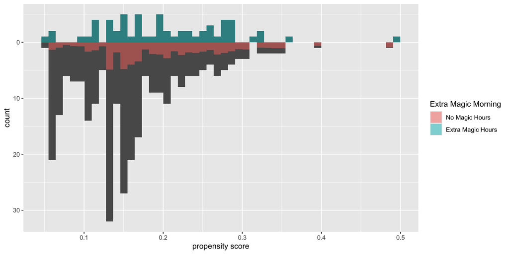